# report_UKCS_fields_exploratory_analysis

Arturo Regalado

29/7/2020

# Data

The section below describes the data processing procedures used to achieve the objective set out for the technical note. Namely: to carry out an exploratory analysis of the levels of production and field sizes in the UKCS to inform the design of model fields for further use in the financial model for the dissertation.

Production data for the UKCS was retrieved from the Oil & Gas Authority (OGA) Open Data repository[^1]. The repository holds monthly production data from June 1975 to April 2020.

**Data preparation** involved the following steps:

- Calculate production in thousand barrels of oil equivalent (mboe) so comparisons between production of different hydrocarbons (oil, natural gas and condensates) is possible. The conversion factor for gas is $1/5800$[^2].
- Use only oil producing offshore fields.
- An implied oil to gas ratio was calculated to identify the share of production in mboe from oil and associated gas for each oil field.
- Data were contrasted to the OGA production dashboard to ensure consistency with the results. The small differences arise due to rounding errors in calculations.

**Sample**

# Exploratory analysis

## Oil production in the UKCS

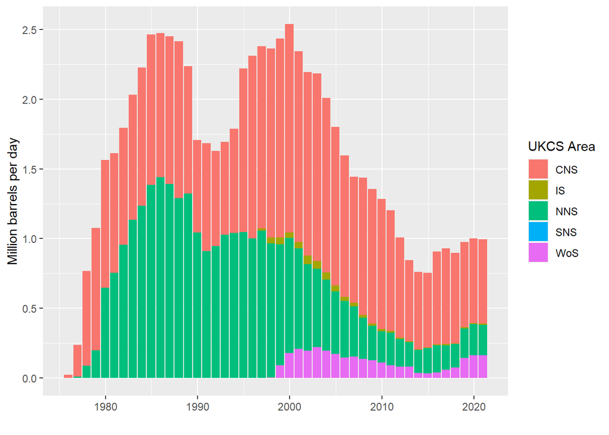

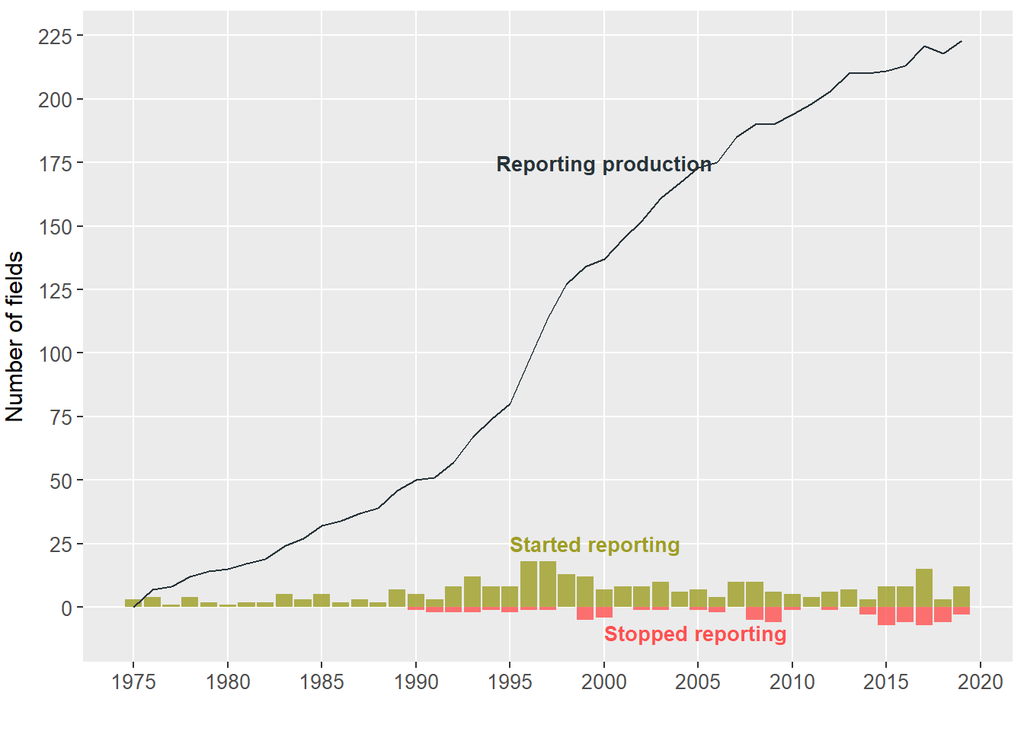

[figure not shown]

```r
grid.arrange(p1, p2, p3,
             p4, p5, nrow = 3,
             top=textGrob(
               "Cumulative distribution function of oil fields production by vintage",gp=gpar(fontface=2, fontsize=16),
               hjust = .5, vjust = 0.2),
             bottom=textGrob(
               "Note: X axis = Total million barrels oil equivalent produced; Y axis = cumulative probability",gp=gpar(fontface=2, fontsize=11),
               hjust = .1))
```

[^1]: See: https://data-ogauthority.opendata.arcgis.com/pages/production
[^2]: The conversion factor comes from the OGA’s reserves and resources report for 2019. Available at: https://www.ogauthority.co.uk/media/5942/oga_reserves__resources_report_2019_jk.pdf